# Introduction to Senna

2026-03-12

## Introduction

**SENNA** (Stochastic data Embedding with Nearest Neighbourhood Adjustment) provides embedding, clustering, and cell type annotation tools for single-cell data. This vignette demonstrates a workflow using a marker-guided topic model on a 10X Genomics PBMC dataset.

With marker gene information, we can guide topic learning toward known cell types and immediately annotate cells – no gene filtering or feature selection is needed.

## Getting Help

```bash
senna --help
```

```
## ┌──────────┐
## │ ∴@∴ @∴  S│
## │ \|/ \|∴ E│  SENNA
## │ @|∴ .|@ N│  Stochastic data Embedding with
## │..|@..|.·N│  Nearest Neighbourhood Adjustment
## │.*|~·\|~*A│
## └──────────┘
##
## Stochastic data Embedding with Nearest Neighbourhood Adjustment
## Data files of either `.zarr` or `.h5` format.
## We can convert `.mtx` to `.zarr` or `.h5` using `data-beans from-mtx`
##
## Usage: senna [OPTIONS] <COMMAND>
##
## Commands:
##   svd             Embedding data by singular value decomposition
##   topic           Embedding data by topic modelling
##   indexed-topic   Embedding data by indexed topic modelling (adaptive feature windows) [aliases: itopic]
##   annotate-topic  Annotate topics using marker genes (vMF cosine similarity) [aliases: annotate]
##   joint-svd       Embedding data by singular value decomposition on multiple data types
##   joint-topic     Embedding data by topic modelling on multiple data types
##   visualize       Visualize topic/SVD results with spectral embedding [aliases: viz]
##   clustering      Cluster cells based on latent representations
##   help            Print this message or the help of the given subcommand(s)
##
## Options:
##   -v, --verbose
##
##
##   -h, --help
##           Print help (see a summary with '-h')
##
##   -V, --version
##           Print version
```

## Example Workflow

1. Create a data backend from H5 file
2. Fit a marker-guided topic model (no gene QC required)
3. Cluster cells with Leiden community detection
4. Visualize and plot results

### Step 1: Setup and Create Backend

```r
temp_dir <- "temp_senna_vignette"
if (!dir.exists(temp_dir)) dir.create(temp_dir)
```

Convert the 10X H5 file to a zarr backend:

```bash
[ -d "temp_senna_vignette/pbmc.zarr" ] && echo "Skipping: pbmc.zarr exists" && exit 0
data-beans from-h5 \
  10k_Human_PBMC_5p_v3_Ultima_10k_Human_PBMC_5p_v3_Ultima_count_sample_filtered_feature_bc_matrix.h5 \
  -o temp_senna_vignette/pbmc \
  -v
```

```
## Skipping: pbmc.zarr exists
```

### Step 2: Prepare Marker Genes

Create a marker gene file for major PBMC cell types. This is a simple two-column TSV with gene symbol and cell type:

```r
markers <- data.frame(
  gene = c(
    # CD4+ T cells
    "IL7R", "CD4", "TCF7", "LEF1", "CCR7", "MAL", "LDHB",
    # CD8+ T cells
    "CD8A", "CD8B", "GZMK", "GZMA", "CCL5", "CST7", "GZMH",
    # B cells
    "CD79A", "CD79B", "MS4A1", "CD19", "BANK1", "PAX5",
    # NK cells
    "GNLY", "KLRD1", "KLRF1", "PRF1", "GZMB", "KLRB1", "NKG7",
    # CD14+ Monocytes
    "CD14", "LYZ", "S100A9", "S100A8", "VCAN", "FCN1", "S100A12",
    # FCGR3A+ Monocytes
    "FCGR3A", "MS4A7", "LST1", "IFITM3", "AIF1", "CDKN1C",
    # Dendritic cells
    "FCER1A", "CST3", "CLEC10A", "CD1C", "HLA-DPB1", "HLA-DQA1", "IRF8",
    # Platelets
    "PPBP", "PF4", "GP9", "ITGA2B", "TUBB1", "GNG11"
  ),
  cell_type = c(
    rep("CD4+ T cells", 7),
    rep("CD8+ T cells", 7),
    rep("B cells", 6),
    rep("NK cells", 7),
    rep("CD14+ Monocytes", 7),
    rep("FCGR3A+ Monocytes", 6),
    rep("Dendritic cells", 7),
    rep("Platelets", 6)
  )
)

write.table(markers, "temp_senna_vignette/pbmc_markers.tsv",
            sep = "\t", row.names = FALSE, col.names = FALSE, quote = FALSE)

cat("Marker genes:", nrow(markers), "genes across",
    length(unique(markers$cell_type)), "cell types\n")
```

```
## Marker genes: 53 genes across 8 cell types
```

```r
table(markers$cell_type)
```

```
##
##           B cells   CD14+ Monocytes      CD4+ T cells      CD8+ T cells
##                 6                 7                 7                 7
##   Dendritic cells FCGR3A+ Monocytes          NK cells         Platelets
##                 7                 6                 7                 6
```

### Step 3: Fit Marker-Guided Topic Model

The topic model can incorporate marker genes during training via `--marker-genes`, biasing topics toward known cell types. No gene QC or feature selection is needed. The model outputs an alignment matrix that maps topics to cell types:

```bash
[ -f "temp_senna_vignette/pbmc_topic.latent.parquet" ] && echo "Skipping: topic exists" && exit 0
senna topic \
  temp_senna_vignette/pbmc.zarr \
  -o temp_senna_vignette/pbmc_topic \
  -t 10 \
  --marker-genes temp_senna_vignette/pbmc_markers.tsv \
  --marker-weight 1.0 \
  -i 1000 \
  -v
```

```
## Skipping: topic exists
```

### Step 4: Cluster Cells with Leiden

Run Leiden community detection on the topic model latent space:

```bash
[ -f "temp_senna_vignette/pbmc_leiden.clusters.parquet" ] && echo "Skipping: leiden exists" && exit 0
senna clustering \
  -l temp_senna_vignette/pbmc_topic.latent.parquet \
  -m leiden \
  --knn 15 \
  --resolution 1.0 \
  -o temp_senna_vignette/pbmc_leiden \
  -v
```

```
## Skipping: leiden exists
```

### Step 5: Visualize with Tree Layout

Create 2D coordinates from the topic model embedding:

```bash
[ -f "temp_senna_vignette/pbmc_viz.cell_coords.parquet" ] && echo "Skipping: viz exists" && exit 0
senna visualize \
  temp_senna_vignette/pbmc.zarr \
  -l temp_senna_vignette/pbmc_topic.latent.parquet \
  -o temp_senna_vignette/pbmc_viz \
  --layout tree \
  -v
```

```
## Skipping: viz exists
```

### Step 6: Derive Cell Type Annotations

The marker-guided topic model produces an `alignment.parquet` that maps each topic to cell types. We can assign each cell its most likely cell type by combining the per-cell topic proportions with the topic-cell type alignment:

```r
library(arrow)
```

```r
library(ggplot2)
library(dplyr)
# Read outputs
coords <- read_parquet("temp_senna_vignette/pbmc_viz.cell_coords.parquet")
clusters <- read_parquet("temp_senna_vignette/pbmc_leiden.clusters.parquet")
latent <- read_parquet("temp_senna_vignette/pbmc_topic.latent.parquet")
alignment <- read_parquet("temp_senna_vignette/pbmc_topic.alignment.parquet")

# alignment: cell types (rows) x topics (columns)
cell_types <- alignment$celltype
align_mat <- as.matrix(alignment[, -1])  # cell_type x topic

# latent: cells x topics (log-softmax scale)
topic_cols <- setdiff(colnames(latent), "cell")
theta <- as.matrix(latent[, topic_cols])
theta <- exp(theta)  # convert to proportions
theta <- theta / rowSums(theta)

# Cell type scores: multiply topic proportions by alignment
# (n_cells x n_topics) %*% t(n_celltypes x n_topics) = n_cells x n_celltypes
scores <- theta %*% t(align_mat)
colnames(scores) <- cell_types

# Assign each cell to its top-scoring cell type
cell_annot <- data.frame(
  cell = latent$cell,
  cell_type = cell_types[apply(scores, 1, which.max)]
)
cell_annot$cell_type <- gsub("_", " ", cell_annot$cell_type)

table(cell_annot$cell_type)
```

```
##
##         B cells CD14+ Monocytes    CD4+ T cells
##             118            2104            7284
```

### Step 7: Topic-Cell Type Alignment

Examine the alignment matrix showing how topics map to cell types:

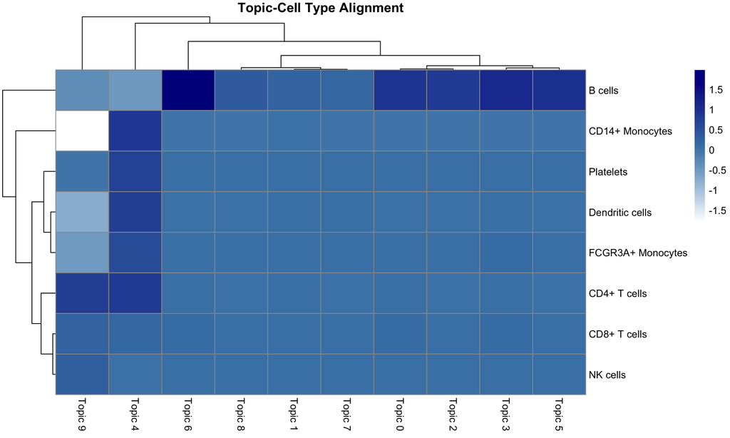

```r
library(pheatmap)

rownames(align_mat) <- gsub("_", " ", cell_types)
colnames(align_mat) <- paste0("Topic ", 0:(ncol(align_mat) - 1))

pheatmap(align_mat,
         color = colorRampPalette(c("white", "steelblue", "darkblue"))(100),
         cluster_rows = TRUE, cluster_cols = TRUE,
         fontsize_row = 10, fontsize_col = 10,
         main = "Topic-Cell Type Alignment")
```

### Step 8: Plot Results

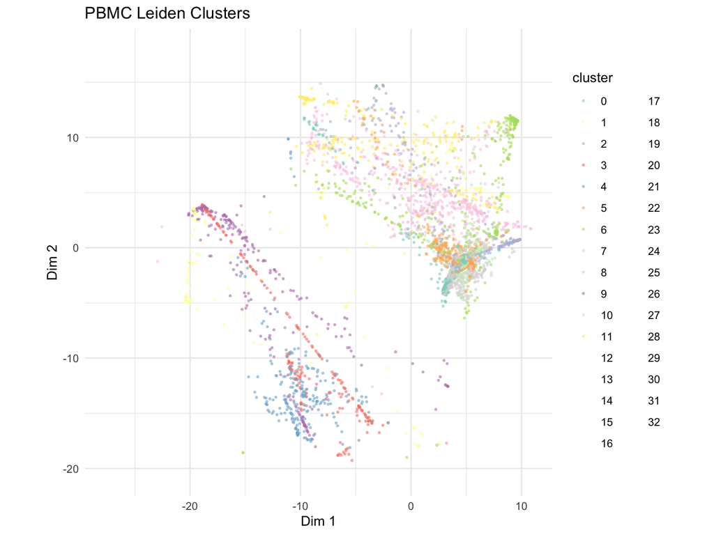

```r
# Merge coordinates with cluster and cell type annotations
df <- coords %>%
  left_join(clusters, by = "cell") %>%
  left_join(cell_annot, by = "cell") %>%
  mutate(cluster = factor(cluster))

ggplot(df, aes(x = x, y = y, color = cluster)) +
  geom_point(alpha = 0.5, size = 0.5) +
  theme_minimal() +
  labs(title = "PBMC Leiden Clusters", x = "Dim 1", y = "Dim 2") +
  coord_fixed() +
  scale_color_brewer(palette = "Set3")
```

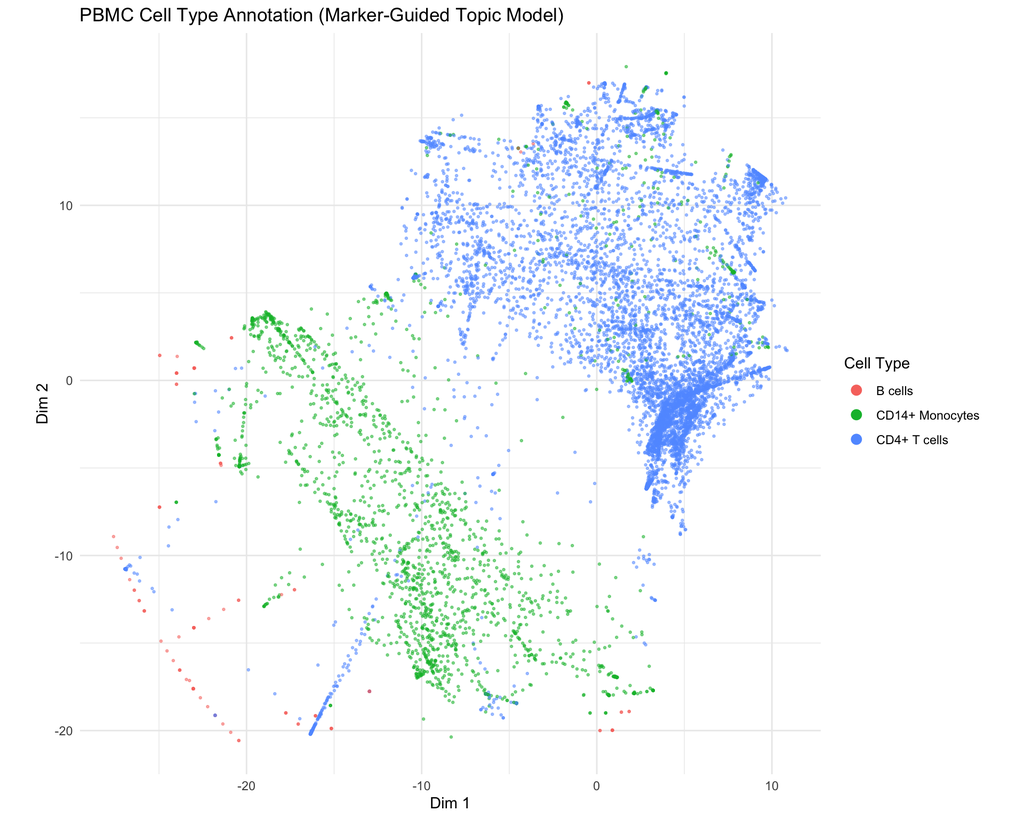

```r
ggplot(df, aes(x = x, y = y, color = cell_type)) +
  geom_point(alpha = 0.5, size = 0.5) +
  theme_minimal() +
  labs(title = "PBMC Cell Type Annotation (Marker-Guided Topic Model)",
       x = "Dim 1", y = "Dim 2", color = "Cell Type") +
  coord_fixed() +
  guides(color = guide_legend(override.aes = list(size = 3, alpha = 1)))
```

### Step 9: Cell Type Composition per Cluster

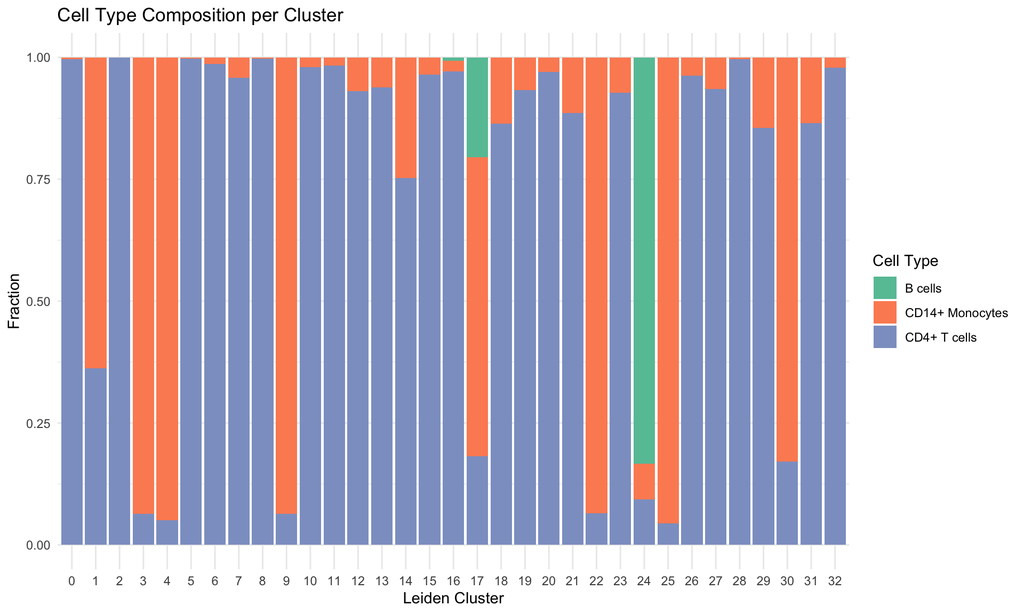

```r
ct_table <- df %>%
  filter(!is.na(cluster), !is.na(cell_type)) %>%
  count(cluster, cell_type) %>%
  group_by(cluster) %>%
  mutate(frac = n / sum(n))

ggplot(ct_table, aes(x = cluster, y = frac, fill = cell_type)) +
  geom_bar(stat = "identity") +
  theme_minimal() +
  labs(title = "Cell Type Composition per Cluster",
       x = "Leiden Cluster", y = "Fraction", fill = "Cell Type") +
  scale_fill_brewer(palette = "Set2")
```